# Observational Analysis

Anonymous

2025-02-17

This notebook contains the observational analysis of the impact of requirements quality (RQ) on trace link recovery (TLR).

## Data Loading

First, load the data for the observational analysis. The data set is procured by the data-preparation.Rmd notebook. This notebook assembles and casts the data appropriately and stores the results in the `rq4tlr-dtata.csv` file.

```r
df <- read.csv('./data/rq4tlr-data.csv')

head(df)
```

```
##   Dataset File duplicate nameproblem scope textorder iounquantified actoractor
## 1   etour  UC1     FALSE       FALSE FALSE     FALSE          FALSE      FALSE
## 2   etour UC10     FALSE       FALSE FALSE     FALSE          FALSE      FALSE
## 3   etour UC11     FALSE       FALSE FALSE     FALSE          FALSE      FALSE
## 4   etour UC12     FALSE       FALSE FALSE     FALSE          FALSE      FALSE
## 5   etour UC13     FALSE       FALSE FALSE     FALSE          FALSE      FALSE
## 6   etour UC14     FALSE       FALSE FALSE     FALSE          FALSE      FALSE
##   justification coordambiguity uidesign alternative inconsistentloa
## 1         FALSE           0.00        0           0               0
## 2         FALSE           0.00        0           0               0
## 3         FALSE           0.00        0           0               0
## 4         FALSE           0.00        0           0               0
## 5         FALSE           0.75        0           0               0
## 6         FALSE           0.00        0           0               0
##   clarification happy size meanactor meanuc coherence outlinks maxinlinks
```

[output cut: 27 more lines]

## Analysis

The analysis of the data employs a regression model in a Bayesian framework.

### Distribution

The three outcome variables `Precision`, `Recall`, and `F1` are all bounded $\in [0, 1]$. This makes a **Beta** distribution an eligible target distribution of the response variables. To determine which variant of the Beta distribution family can be chosen, we visualize the raw distribution.

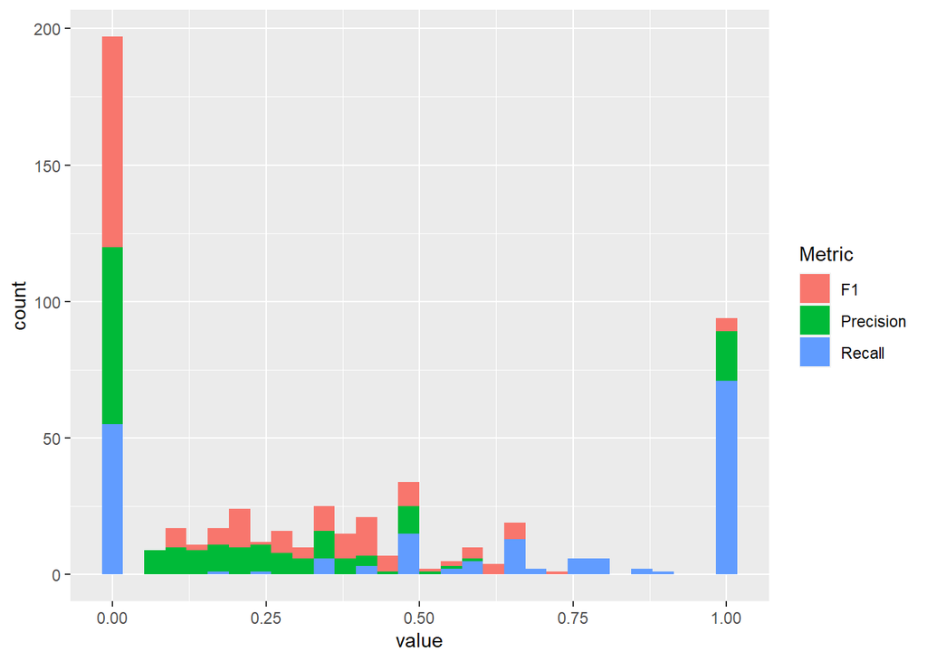

```r
df %>%
  select(c(Precision, Recall, F1)) %>%
  pivot_longer(cols=c(Precision, Recall, F1), names_to = "Metric") %>%
  ggplot(aes(x = value, fill=Metric)) +
    geom_histogram()
```

A base Beta distribution would require that all values are bounded within $]0; 1[$. The observed values for the three outcome variables show a clear zero- and one-inflation. Hence, we chose the `zero_one_inflated_beta` distribution from the `brms` library.

### Formula

Next, we define regression formulae that put the outcome variable of interest in relation to the predictors with which we assume a causal relationship.

```r
f1 <- F1 ~ 0 + Intercept + Dataset + sencomplexity + maxsteplength + size + inconsistentloa + uidesign + clarification + alternative + coherence + happy + lostfr + anaphora + nonnounstart + passive + negation + outlinks + maxinlinks
#f2 <- bf(
#  mvbind(Precision, Recall, F1) ~ 0 + Intercept + Dataset + sencomplexity + maxsteplength + size + inconsistentloa + uidesign + happy,
#  family = zero_one_inflated_beta
#)
```

The `0 + Intercept` term instead of `1 +` or even complete omission stems from the fact that the regression formula contains at least one predictor that is not centered around 0.

### Priors

The selected regression formula requires the definition of prior distributions for the following parameters.

```r
get_prior(f1, data=df, family=zero_one_inflated_beta)
```

```
##              prior class            coef group resp dpar nlpar lb ub
##             (flat)     b
##             (flat)     b     alternative
##             (flat)     b        anaphora
##             (flat)     b   clarification
##             (flat)     b       coherence
##             (flat)     b   Datasetitrust
##             (flat)     b       happyTRUE
##             (flat)     b inconsistentloa
##             (flat)     b       Intercept
##             (flat)     b      lostfrTRUE
##             (flat)     b      maxinlinks
##             (flat)     b   maxsteplength
##             (flat)     b        negation
##             (flat)     b    nonnounstart
##             (flat)     b        outlinks
##             (flat)     b         passive
##             (flat)     b   sencomplexity
##             (flat)     b            size
##             (flat)     b        uidesign
##         beta(1, 1)   coi                                        0  1
##  gamma(0.01, 0.01)   phi                                        0
##         beta(1, 1)   zoi                                        0  1
##        source
##       default
##  (vectorized)
##  (vectorized)
##  (vectorized)
##  (vectorized)
##  (vectorized)
##  (vectorized)
##  (vectorized)
##  (vectorized)
##  (vectorized)
##  (vectorized)
##  (vectorized)
##  (vectorized)
##  (vectorized)
##  (vectorized)
##  (vectorized)
##  (vectorized)
##  (vectorized)
##  (vectorized)
##       default
##       default
##       default
```

We select the following priors:

```r
p1 <- c(
  prior(normal(0, 1), class = b, coef = "Intercept"),
  prior(normal(0, 0.5), class = b),
  prior(gamma(4, 1), class = phi),
  prior(beta(7, 2), class = coi),
  prior(beta(5, 2), class = zoi)
)
```

### Prior Predictive Check

The prior predictive check helps determine the eligibility of the priors.

```r
m1.prior <-
  brm(data = df, family = zero_one_inflated_beta, f1, prior = p1,
    iter = 4000, warmup = 1000, chains = 4, cores = 4,
    seed = 4, sample_prior="only",
    file = "fits/obs.f1.prior"
  )
```

In our particular case, the large number of predictors will, however, push the accumulated value of $\mu$ in the Beta-distribution to the to extremes.

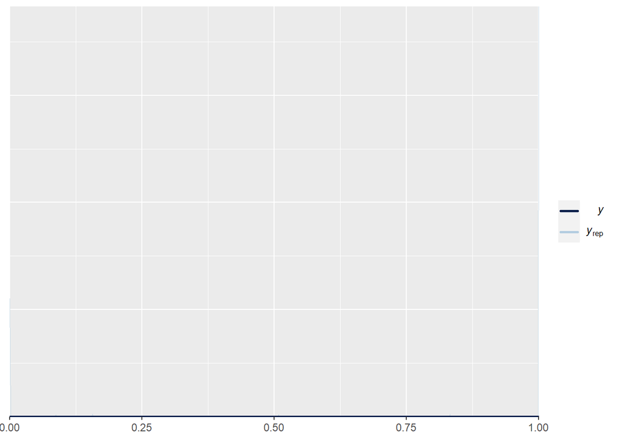

```r
brms::pp_check(m1.prior, ndraws=100)
```

The figure shows extreme concentrations of expected values $y_{rep}$ on the borders of the output space (at 0 and 1). Instead, we put more emphasis on the posterior predictive check.

### Training

Assuming the priors are reliable, we train the model by updating the coefficient parameters with the data `df`.

```r
m1 <-
  brm(data = df, family = zero_one_inflated_beta, f1, prior = p1,
    iter = 4000, warmup = 1000, chains = 4, cores = 4, seed = 4,
    file = "fits/obs.f1"
  )
```

To check whether the training completed successfully, we inspect the posterior predictive check.

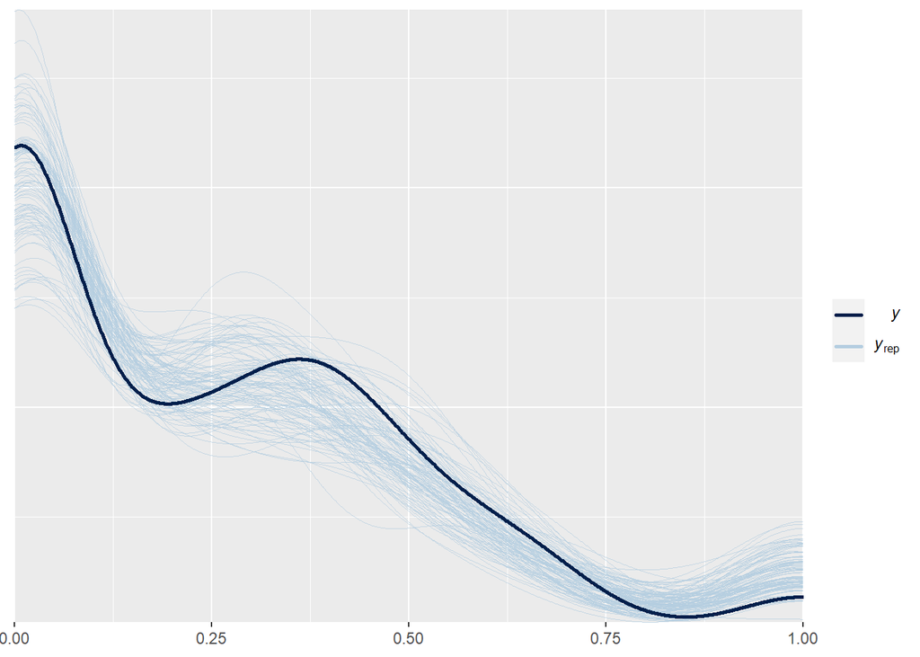

```r
brms::pp_check(m1, ndraws=100)
```

The output confirms that the model parameters have been updated properly and that the predicted outcomes $y_{rep}$ are close the the actual outcome $y$.

### Evaluation

Finally, we evaluate the model.

#### Coefficients

First, we look at the updated path coefficients in the model summary.

```r
summary(m1)
```

```
##  Family: zero_one_inflated_beta
##   Links: mu = logit; phi = identity; zoi = identity; coi = identity
## Formula: F1 ~ 0 + Intercept + Dataset + sencomplexity + maxsteplength + size + inconsistentloa + uidesign + clarification + alternative + coherence + happy + lostfr + anaphora + nonnounstart + passive + negation + outlinks + maxinlinks
##    Data: df (Number of observations: 189)
##   Draws: 4 chains, each with iter = 4000; warmup = 1000; thin = 1;
##          total post-warmup draws = 12000
##
## Population-Level Effects:
##                 Estimate Est.Error l-95% CI u-95% CI Rhat Bulk_ESS Tail_ESS
## Intercept          -0.63      0.33    -1.28     0.02 1.00     9929     8586
## Datasetitrust       0.05      0.26    -0.47     0.56 1.00    10602     8966
## sencomplexity      -0.01      0.04    -0.09     0.08 1.00    10439     7788
## maxsteplength      -0.00      0.01    -0.02     0.02 1.00    10636     8027
## size               -0.00      0.01    -0.02     0.01 1.00    14348    10193
## inconsistentloa     0.47      0.30    -0.13     1.06 1.00    16495     8761
## uidesign           -0.07      0.47    -0.99     0.85 1.00    16173     8933
## clarification      -0.15      0.29    -0.73     0.41 1.00    17798     9071
## alternative        -0.31      0.38    -1.05     0.45 1.00    16692     9389
## coherence          -0.06      0.21    -0.47     0.34 1.00    12966     8499
## happyTRUE           0.11      0.20    -0.27     0.49 1.00    11634     9363
## lostfrTRUE          0.07      0.28    -0.48     0.62 1.00    16752     8579
## anaphora           -0.25      0.25    -0.74     0.24 1.00    15666     9213
## nonnounstart       -0.28      0.23    -0.74     0.18 1.00    11173     8701
## passive            -0.08      0.28    -0.63     0.48 1.00    13495     9585
## negation            0.34      0.37    -0.40     1.05 1.00    16712     8589
## outlinks            0.12      0.04     0.05     0.19 1.00    13485     9440
## maxinlinks         -0.02      0.01    -0.03     0.00 1.00    14923     8841
##
## Family Specific Parameters:
##     Estimate Est.Error l-95% CI u-95% CI Rhat Bulk_ESS Tail_ESS
## phi     9.30      1.23     7.05    11.84 1.00    14311     9006
## zoi     0.44      0.04     0.37     0.51 1.00    18850     8132
## coi     0.13      0.04     0.07     0.21 1.00    16358     7395
##
## Draws were sampled using sampling(NUTS). For each parameter, Bulk_ESS
## and Tail_ESS are effective sample size measures, and Rhat is the potential
## scale reduction factor on split chains (at convergence, Rhat = 1).
```

These coefficients can also be visualized via a `mcmc_plot`.

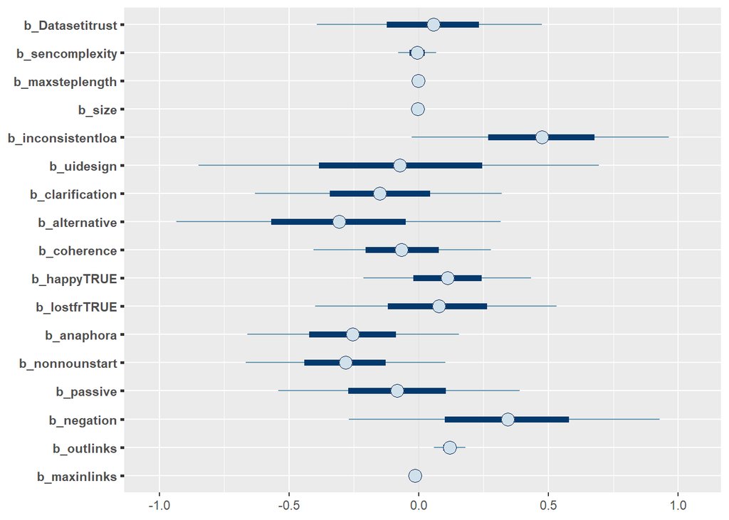

```r
mcmc_plot(m1, variable=c("b_Datasetitrust", "b_sencomplexity", "b_maxsteplength", "b_size", "b_inconsistentloa", "b_uidesign", "b_clarification", "b_alternative", "b_coherence", "b_happyTRUE", "b_lostfrTRUE", "b_anaphora", "b_nonnounstart", "b_passive", "b_negation", "b_outlinks", "b_maxinlinks"))
```

Variables, where the 50% confidence interval of the intercept does not overlap 0, weakly impact the response variable. Variables, where the 95% confidence interval of the intercept does not overlap 0, strongly impact the response variable.

#### Marginal Distributions

For a clearer picture, we can plot the marginal distributions of the outcome variable when manipulating one specific factor while keeping the others at a constant level.

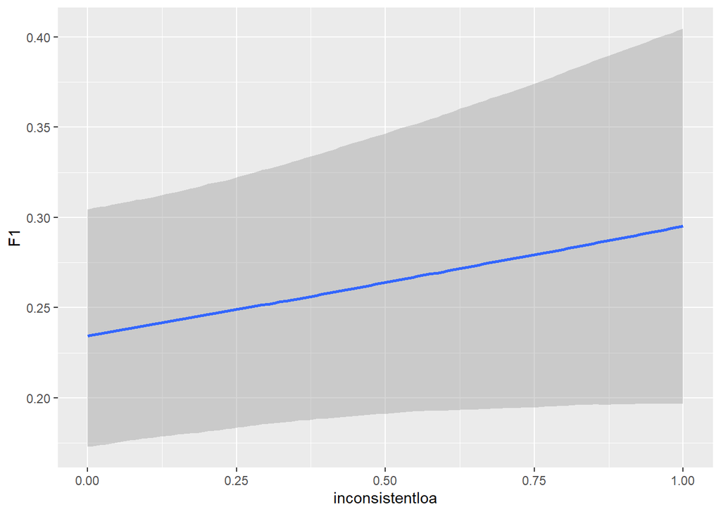

```r
conditional_effects(m1, effects="inconsistentloa", method="posterior_epred")
```

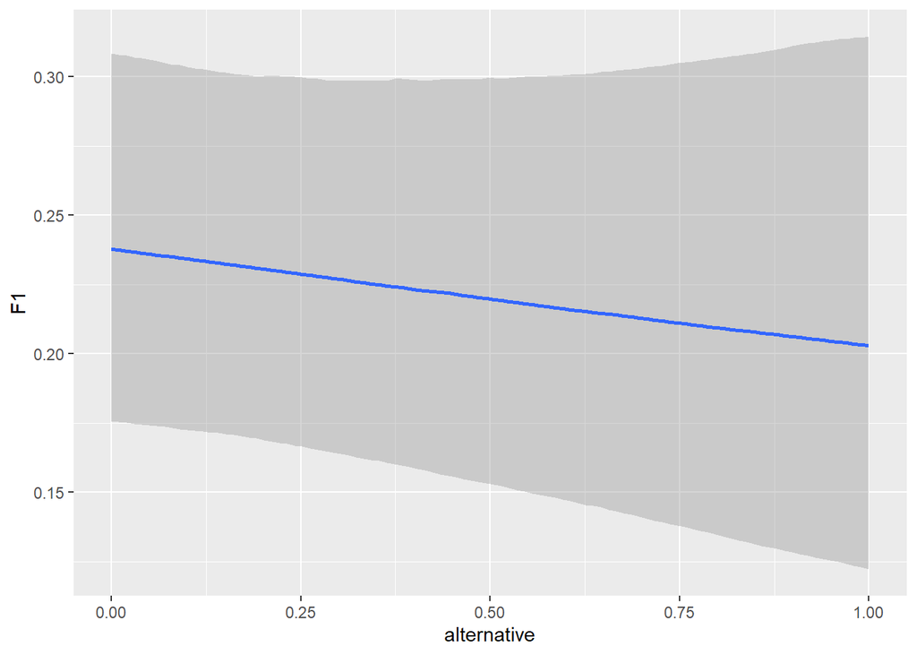

```r
conditional_effects(m1, effects="alternative", method="posterior_epred")
```

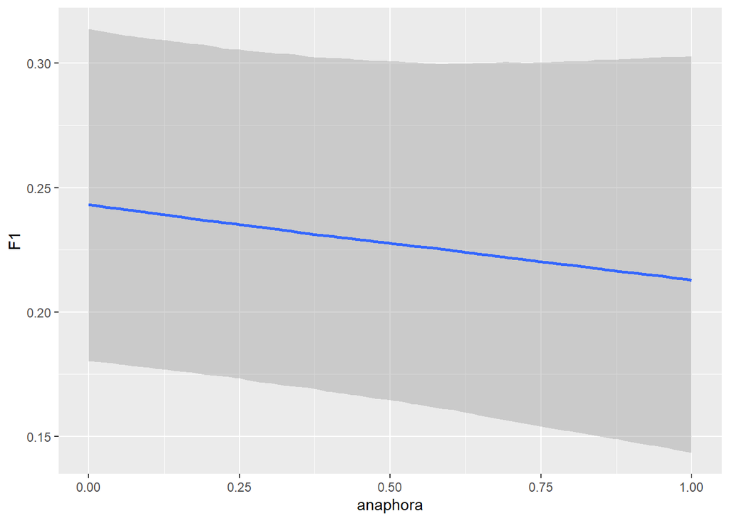

```r
conditional_effects(m1, effects="anaphora", method="posterior_epred")
```

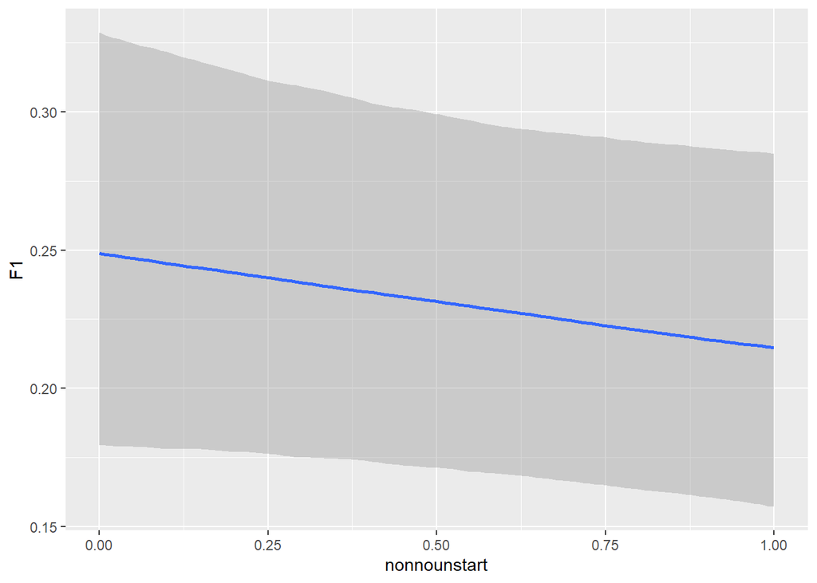

```r
conditional_effects(m1, effects="nonnounstart", method="posterior_epred")
```

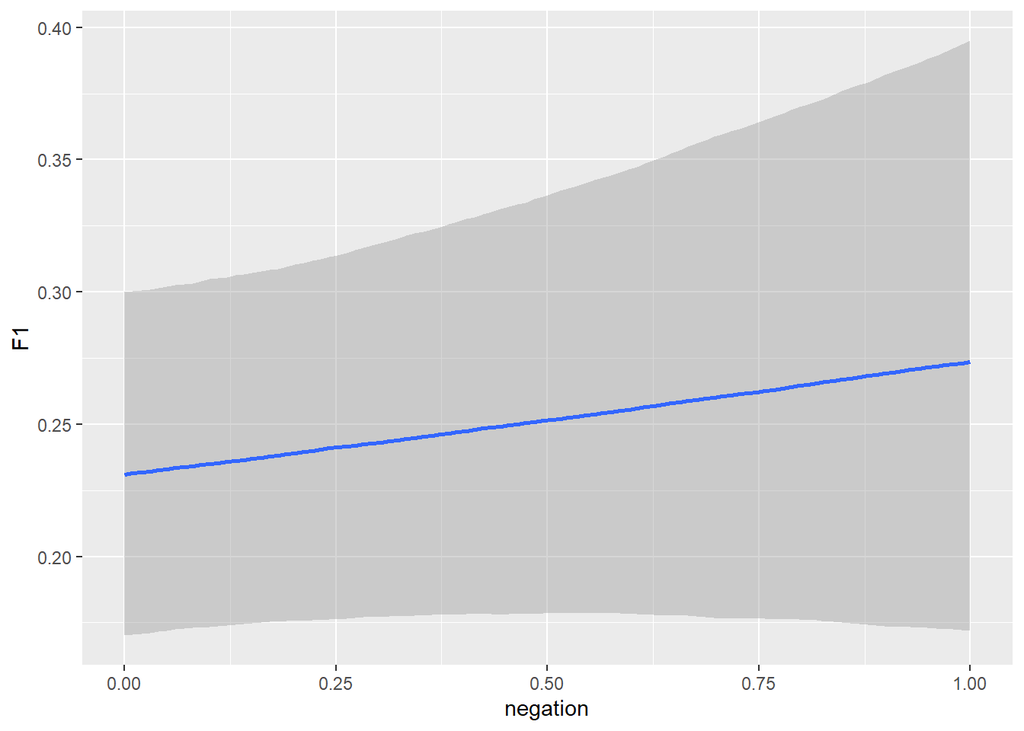

```r
conditional_effects(m1, effects="negation", method="posterior_epred")
```

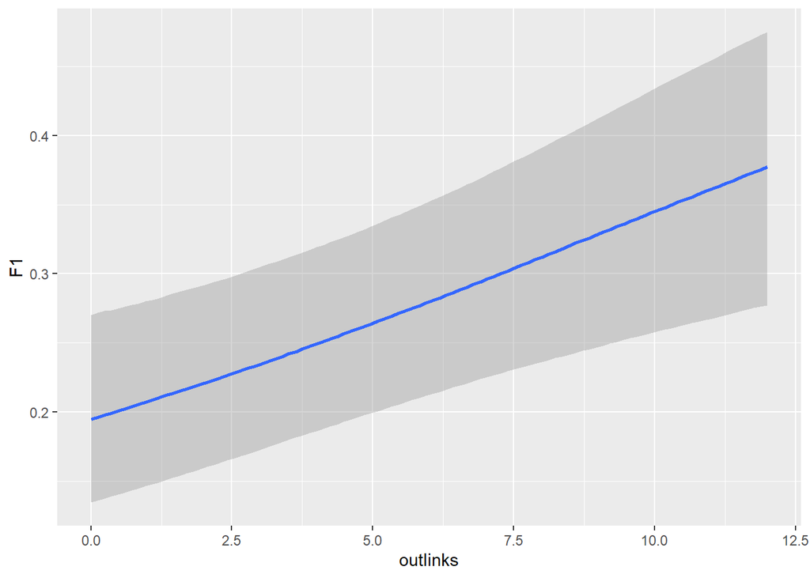

```r
conditional_effects(m1, effects="outlinks", method="posterior_epred")
```